# Pertemuan 3 - Regresi dengan Peubah Lag

G1401211082_Windi Gunawan

## Impor Data

```r
data <- rio::import("https://raw.githubusercontent.com/yoginurhamid/MPDW/main/Pertemuan%203/Californa_Wine_Production_1980_2020.csv")
str(data)
```

```
## 'data.frame':    1315 obs. of  11 variables:
##  $ Year               : int  2020 2020 2020 2020 2020 2020 2020 2020 2020 2020 ...
##  $ CommodityCode      : int  216299 216299 216299 216299 216299 216299 216299 216299 216299 216299 ...
##  $ CropName           : chr  "GRAPESWINE" "GRAPESWINE" "GRAPESWINE" "GRAPESWINE" ...
##  $ CountyCode         : int  1 5 9 11 13 17 19 29 31 33 ...
##  $ County             : chr  "Alameda" "Amador" "Calaveras" "Colusa" ...
##  $ HarvestedAcres     : int  2530 5360 579 747 1940 2620 56900 25200 3590 9580 ...
##  $ Yield(Unit/Acre)   : num  5.14 2.31 3.06 6.02 4.69 ...
##  $ Production         : int  13000 12400 1770 4500 9090 6240 690000 190000 59100 39500 ...
##  $ Price(Dollars/Unit): num  1498 1318 1326 685 751 ...
##  $ Unit               : chr  "Tons" "Tons" "Tons" "Tons" ...
##  $ Value(Dollars)     : int  19470000 16347000 2347000 3081000 6829000 9663000 249877000 59668000 16954000 52510000 ...
```

```r
data
```

```
##      Year CommodityCode   CropName CountyCode        County HarvestedAcres
## 1    2020        216299 GRAPESWINE          1       Alameda           2530
## 2    2020        216299 GRAPESWINE          5        Amador           5360
## 3    2020        216299 GRAPESWINE          9     Calaveras            579
## 4    2020        216299 GRAPESWINE         11        Colusa            747
## 5    2020        216299 GRAPESWINE         13   ContraCosta           1940
## 6    2020        216299 GRAPESWINE         17      ElDorado           2620
## 7    2020        216299 GRAPESWINE         19        Fresno          56900
## 8    2020        216299 GRAPESWINE         29          Kern          25200
## 9    2020        216299 GRAPESWINE         31         Kings           3590
## 10   2020        216299 GRAPESWINE         33          Lake           9580
## 11   2020        216299 GRAPESWINE         39        Madera          33000
## 12   2020        216299 GRAPESWINE         41         Marin            195
## 13   2020        216299 GRAPESWINE         45     Mendocino          16400
## 14   2020        216299 GRAPESWINE         47        Merced          13200
```

[output cut: 2617 more lines]

#Merapihkan data

```r
#Mengambil data daerah Fresno
data <- data[data$County == "Fresno",]

#Membalik data sesuai urutan tahun terlama
flip <- function(data){
  new <- data[rev(rownames(data)),]
  rownames(new) <- NULL
  new
}
data <- flip(data)

#Mengambil data yang digunakan
t <- data$Year
Xt <- data$Production
Yt <- data$`Price(Dollars/Unit)`

#Menggabungkan data
data.lag <- cbind.data.frame(t,Yt,Xt)
data.lag
```

```
##       t     Yt      Xt
## 1  1980 174.00  359100
## 2  1981 205.00  292000
## 3  1982 153.00  354600
## 4  1983 160.00  289400
## 5  1984 138.00  298900
## 6  1985 115.00  401900
## 7  1986 138.00  280300
## 8  1987 149.00  283000
## 9  1988 167.00  345100
## 10 1989 186.00  287300
## 11 1990 158.00  346750
## 12 1991 162.00  304780
## 13 1992 195.00  825100
## 14 1993 182.00  667100
```

[output cut: 27 more lines]

## Pembagian Data

```r
#SPLIT DATA
train<-data.lag[1:33,]
test<-data.lag[34:41,]
```

```r
#data time series
train.ts<-ts(train)
test.ts<-ts(test)
data.ts<-ts(data.lag)
```

## Model Koyck

Model Koyck didasarkan pada asumsi bahwa semakin jauh jarak lag peubah independen dari periode sekarang maka semakin kecil pengaruh peubah lag terhadap peubah dependen.

Koyck mengusulkan suatu metode untuk menduga model dinamis distributed lag dengan mengasumsikan bahwa semua koefisien $\beta$ mempunyai tanda sama.

Model kyock merupakan jenis paling umum dari model infinite distributed lag dan juga dikenal sebagai geometric lag

$$y_t=a(1-\lambda)+\beta_0X_t+\beta_1Z_t+\lambda Y_{t-1}+V_t$$

dengan
$$V_t=u_t-\lambda
u_{t-1}$$

### Pemodelan

Pemodelan model Koyck dengan `R` dapat menggunakan `dLagM::koyckDlm()` . Fungsi umum dari `koyckDlm` adalah sebagai berikut.

```r
koyckDlm(Xt , Yt)
```

Fungsi `koyckDlm()` akan menerapkan model lag terdistribusi dengan transformasi Koyck satu prediktor. Nilai `x` dan `y` tidak perlu sebagai objek *time series* (`ts`). `intercept` dapat dibuat `TRUE` untuk memasukkan intersep ke dalam model.

```r
#MODEL KOYCK
model.koyck <- koyckDlm(x = train$Xt, y = train$Yt)
summary(model.koyck)
```

```
##
## Call:
## "Y ~ (Intercept) + Y.1 + X.t"
##
## Residuals:
##     Min      1Q  Median      3Q     Max
## -71.834 -18.293   2.403  18.432  44.245
##
## Coefficients:
##               Estimate Std. Error t value Pr(>|t|)
## (Intercept) -5.682e+00  2.175e+01  -0.261    0.796
## Y.1          9.585e-01  1.909e-01   5.022 2.39e-05 ***
## X.t          3.275e-05  4.643e-05   0.705    0.486
## ---
## Signif. codes:  0 '***' 0.001 '**' 0.01 '*' 0.05 '.' 0.1 ' ' 1
##
## Residual standard error: 28.44 on 29 degrees of freedom
## Multiple R-Squared: 0.7729,  Adjusted R-squared: 0.7572
## Wald test: 48.66 on 2 and 29 DF,  p-value: 5.417e-10
##
## Diagnostic tests:
## NULL
##
##                              alpha         beta       phi
## Geometric coefficients:  -136.9069 3.274658e-05 0.9584943
```

```r
AIC(model.koyck)
```

```
## [1] 309.9293
```

```r
BIC(model.koyck)
```

```
## [1] 315.7923
```

$$\hat{Y_t}=(-5.682e+00)+(3.275e-05)X_t+(9.585e-01)Y_{t-1}$$

### Peramalan Model Koyck

Berikut adalah hasil peramalan y untuk 8 periode kedepan menggunakan model koyck

```r
fore.koyck <- forecast(model = model.koyck, x=test$Xt, h=8)
fore.koyck
```

```
## $forecasts
## [1] 387.2445 387.1020 390.5675 393.3979 397.4208 400.4252 402.3553 402.5680
##
## $call
## forecast.koyckDlm(model = model.koyck, x = test$Xt, h = 8)
##
## attr(,"class")
## [1] "forecast.koyckDlm" "dLagM"
```

## Akurasi Model Koyck

```r
#mape data testing
mape.koyck <- MAPE(fore.koyck$forecasts, test$Yt)

#akurasi data training
mape_train <- dLagM::GoF(model.koyck)["MAPE"]

c("MAPE_testing" = mape.koyck, "MAPE_training" = mape_train)
```

```
## $MAPE_testing
## [1] 0.1000894
##
## $MAPE_training.MAPE
## [1] 0.1204038
```

Model Koyck merupakan peramalan model yang baik dengan nilai MAPE yang berkisar antara 10-20%.

## Regression with Distributed Lag

Fungsi `dlm()` akan menerapkan model lag terdistribusi dengan satu atau lebih prediktor. Nilai `x` dan `y` tidak perlu sebagai objek *time series* (`ts`). $q$ adalah integer yang mewakili panjang *lag* yang terbatas.

```r
#penentuan lag optimum
finiteDLMauto(formula = Yt ~ Xt,
              data = data.frame(train), model.type = "dlm", error.type = "AIC", trace = FALSE)
```

```
##    q - k    MASE      AIC      BIC   GMRAE   MBRAE R.Adj.Sq  Ljung-Box
## 10    10 1.16808 252.4039 267.1654 1.05754 0.41007  0.30704 0.01312698
```

Berdasarkan output tersebut, lag optimum didapatkan 10 tahun sebelumnya.

```r
#model dlm dengan lag optimum
model.dlm <- dlm(x = train$Xt,y = train$Yt , q = 10)
summary(model.dlm)
```

```
##
## Call:
## lm(formula = model.formula, data = design)
##
## Residuals:
##     Min      1Q  Median      3Q     Max
## -60.847 -30.425  -0.989  31.290  60.415
##
## Coefficients:
##               Estimate Std. Error t value Pr(>|t|)
## (Intercept)  4.625e+01  4.932e+01   0.938   0.3685
## x.t          1.616e-04  7.736e-05   2.090   0.0607 .
## x.1          1.077e-04  7.394e-05   1.456   0.1733
## x.2          5.769e-05  7.196e-05   0.802   0.4397
## x.3         -2.872e-05  7.211e-05  -0.398   0.6980
## x.4          5.437e-06  7.369e-05   0.074   0.9425
## x.5         -2.105e-04  8.158e-05  -2.581   0.0256 *
## x.6         -5.358e-05  7.554e-05  -0.709   0.4929
## x.7          1.899e-05  8.018e-05   0.237   0.8171
## x.8          3.284e-05  7.744e-05   0.424   0.6797
## x.9          3.317e-05  8.233e-05   0.403   0.6947
## x.10         1.244e-04  7.769e-05   1.601   0.1376
## ---
## Signif. codes:  0 '***' 0.001 '**' 0.01 '*' 0.05 '.' 0.1 ' ' 1
##
## Residual standard error: 48.02 on 11 degrees of freedom
## Multiple R-squared:  0.6535, Adjusted R-squared:  0.307
## F-statistic: 1.886 on 11 and 11 DF,  p-value: 0.1538
##
## AIC and BIC values for the model:
##        AIC      BIC
## 1 252.4039 267.1654
```

Dari hasil diatas, didapat bahwa $P-value$ dari $x_{t-5}<0.05$. Hal ini menunjukkan bahwa $x_{t-5}$ berpengaruh signifikan terhadap $y$. Adapun model keseluruhan yang terbentuk adalah sebagai berikutAdapun keseluruhan model yang terbentuk adalah

$$\hat{Y_t}=(4.625e+01)+
(1.616e-04)X_t+(1.077e-04)X_{t-1}+(5.769e-05)X_{t-2}-(2.872e-05)X_{t-3}+(5.437e-06)X_{t-4}-(2.105e-04)X_{t-5}-(5.358e-05)X_{t-6}+(1.899e-05)X_{t-7}+(3.284e-05)X_{t-8}+(3.317e-05)X_{t-9}+
1.244e-04X_{t-10}$$

```r
AIC(model.dlm)
```

```
## [1] 252.4039
```

```r
BIC(model.dlm)
```

```
## [1] 267.1654
```

Adapun hasil peramalan 8 periode kedepan menggunakan model tersebut adalah sebagai berikut

```r
#peramalan
forecast(model = model.dlm, x=test$Xt, h=8)
```

```
## $forecasts
## [1] 191.5173 205.6644 204.7519 179.6017 215.0031 284.4384 275.7735 248.6331
##
## $call
## forecast.dlm(model = model.dlm, x = test$Xt, h = 8)
##
## attr(,"class")
## [1] "forecast.dlm" "dLagM"
```

#Akurasi DLM

```r
#mape data testing
mape.dlm <- MAPE(model.dlm$forecasts, test$Yt)

#akurasi data training
mape_train <- dLagM::GoF(model.dlm)["MAPE"]

c("MAPE_testing" = mape.dlm, "MAPE_training" = mape_train)
```

```
## $MAPE_testing
## [1] NaN
##
## $MAPE_training.MAPE
## [1] 0.1354117
```

## Model Autoregressive

Peubah dependen dipengaruhi oleh peubah independen pada waktu sekarang, serta dipengaruhi juga oleh peubah dependen itu sendiri pada satu waktu yang lalu maka model tersebut disebut *autoregressive* (Gujarati 2004).

### Pemodelan

Pemodelan Autoregressive dilakukan menggunakan fungsi `dLagM::ardlDlm()` . Fungsi tersebut akan menerapkan *autoregressive* .

### *Lag* Optimum

```r
#penentuan lag optimum
model.ardl<- ardlBoundOrders(data = data.frame(data.lag), ic = "AIC",
                                  formula = Yt ~ Xt )
min_p=c()
for(i in 1:15){
  min_p[i]=min(model.ardl$Stat.table[[i]])
}
q_opt=which(min_p==min(min_p, na.rm = TRUE))
p_opt=which(model.ardl$Stat.table[[q_opt]] ==
              min(model.ardl$Stat.table[[q_opt]], na.rm = TRUE))
data.frame("q_optimum" = q_opt, "p_optimum" = p_opt,
           "AIC"=model.ardl$min.Stat)
```

```
##   q_optimum p_optimum     AIC
## 1         4        15 191.611
```

```r
#ARDL MODEL
model.ardl = ardlDlm(x = train$Xt, y = train$Yt, p = 15 , q = 4)
summary(model.ardl)
```

```
##
## Time series regression with "ts" data:
## Start = 16, End = 33
##
## Call:
## dynlm(formula = as.formula(model.text), data = data, start = 1)
##
## Residuals:
## ALL 18 residuals are 0: no residual degrees of freedom!
##
## Coefficients: (3 not defined because of singularities)
##               Estimate Std. Error t value Pr(>|t|)
## (Intercept)  2.800e+02        NaN     NaN      NaN
## X.t          1.578e-04        NaN     NaN      NaN
## X.1          1.845e-04        NaN     NaN      NaN
## X.2         -5.844e-05        NaN     NaN      NaN
## X.3         -2.296e-04        NaN     NaN      NaN
## X.4         -8.156e-05        NaN     NaN      NaN
## X.5         -2.857e-04        NaN     NaN      NaN
## X.6          2.326e-05        NaN     NaN      NaN
## X.7          8.720e-05        NaN     NaN      NaN
## X.8          7.337e-05        NaN     NaN      NaN
## X.9          7.553e-05        NaN     NaN      NaN
## X.10         6.403e-06        NaN     NaN      NaN
## X.11        -1.612e-04        NaN     NaN      NaN
## X.12         2.895e-06        NaN     NaN      NaN
## X.13         1.479e-05        NaN     NaN      NaN
## X.14         3.675e-05        NaN     NaN      NaN
## X.15         3.221e-04        NaN     NaN      NaN
## Y.1         -4.282e-01        NaN     NaN      NaN
## Y.2                 NA         NA      NA       NA
## Y.3                 NA         NA      NA       NA
## Y.4                 NA         NA      NA       NA
##
## Residual standard error: NaN on 0 degrees of freedom
## Multiple R-squared:      1,  Adjusted R-squared:    NaN
## F-statistic:   NaN on 17 and 0 DF,  p-value: NA
```

Melalui model ini diperoleh NaN pada error, t value, dan p-value. Oleh karena itu, nilai p dan q optimum ditelusuri lagi secara manual. Diperoleh p = 11 dan q = 7.

```r
model.ardl = ardlDlm(x = train$Xt, y = train$Yt, p = 11 , q = 7)
summary(model.ardl)
```

```
##
## Time series regression with "ts" data:
## Start = 12, End = 33
##
## Call:
## dynlm(formula = as.formula(model.text), data = data, start = 1)
##
## Residuals:
##        12        13        14        15        16        17        18        19
##   1.32358  -0.91955  -1.81564   0.72779  10.33779 -12.14215  -0.42852   5.14665
##        20        21        22        23        24        25        26        27
##   0.03551  -5.73102   3.98733  -3.77432  -0.16726   5.01358   2.76626  -3.48810
##        28        29        30        31        32        33
##  -3.29369   8.53465   0.27594 -10.34446  -7.44888  11.40450
##
## Coefficients:
##               Estimate Std. Error t value Pr(>|t|)
## (Intercept) -5.571e+01  6.346e+01  -0.878   0.4726
## X.t         -1.217e-05  7.832e-05  -0.155   0.8907
## X.1         -9.514e-05  6.799e-05  -1.399   0.2967
## X.2         -7.878e-05  5.818e-05  -1.354   0.3084
## X.3         -7.111e-05  6.518e-05  -1.091   0.3892
## X.4          1.210e-04  5.655e-05   2.140   0.1657
## X.5         -3.425e-05  6.227e-05  -0.550   0.6376
## X.6          1.817e-05  5.803e-05   0.313   0.7838
## X.7         -5.543e-06  6.468e-05  -0.086   0.9395
## X.8         -2.855e-05  6.028e-05  -0.474   0.6824
## X.9         -6.010e-05  5.602e-05  -1.073   0.3956
## X.10        -6.170e-05  6.809e-05  -0.906   0.4605
## X.11         1.841e-04  5.783e-05   3.183   0.0861 .
## Y.1          1.378e+00  4.944e-01   2.786   0.1083
## Y.2          7.660e-02  7.705e-01   0.099   0.9299
## Y.3          1.210e-01  7.895e-01   0.153   0.8922
## Y.4         -3.503e-01  6.782e-01  -0.517   0.6569
## Y.5         -5.281e-01  6.975e-01  -0.757   0.5280
## Y.6          1.738e+00  6.132e-01   2.834   0.1052
## Y.7         -5.464e-01  4.368e-01  -1.251   0.3375
## ---
## Signif. codes:  0 '***' 0.001 '**' 0.01 '*' 0.05 '.' 0.1 ' ' 1
##
## Residual standard error: 19.64 on 2 degrees of freedom
## Multiple R-squared:  0.9889, Adjusted R-squared:  0.8833
## F-statistic: 9.368 on 19 and 2 DF,  p-value: 0.1007
```

Melalui model ARDL tidak diperoleh peubah yang berpengaruh secara signifikan. Model ini cukup baik dengan nilai R-Square sebesar 98.89%.

```r
AIC(model.ardl)
```

```
## [1] 182.6992
```

```r
BIC(model.ardl)
```

```
## [1] 205.6111
```

#Peramalan ARDL

```r
forecast(model = model.ardl, x=test$Xt, h=8)
```

```
## $forecasts
## [1]  463.3032  633.9681  884.1423 1260.5832 1741.8588 2429.9116 3470.5667
## [8] 4952.4814
##
## $call
## forecast.ardlDlm(model = model.ardl, x = test$Xt, h = 8)
##
## attr(,"class")
## [1] "forecast.ardlDlm" "dLagM"
```

#Akurasi ARDL

```r
# mape akurasi testing
mape.ardl <- MAPE(model.ardl$forecasts, test$Yt) #data testing

# mape akurasi data training
mape_train <- GoF(model.ardl)["MAPE"]

c("MAPE_testing" = mape.ardl, "MAPE_training" = mape_train)
```

```
## $MAPE_testing
## [1] NaN
##
## $MAPE_training.MAPE
## [1] 0.0196229
```

## Perbandingan Model

```r
akurasi <- matrix(c(mape.koyck, mape.dlm, mape.ardl))
row.names(akurasi)<- c("Koyck","DLM","ARDL")
colnames(akurasi) <- c("MAPE")
akurasi
```

```
##            MAPE
## Koyck 0.1000894
## DLM         NaN
## ARDL        NaN
```

### Plot

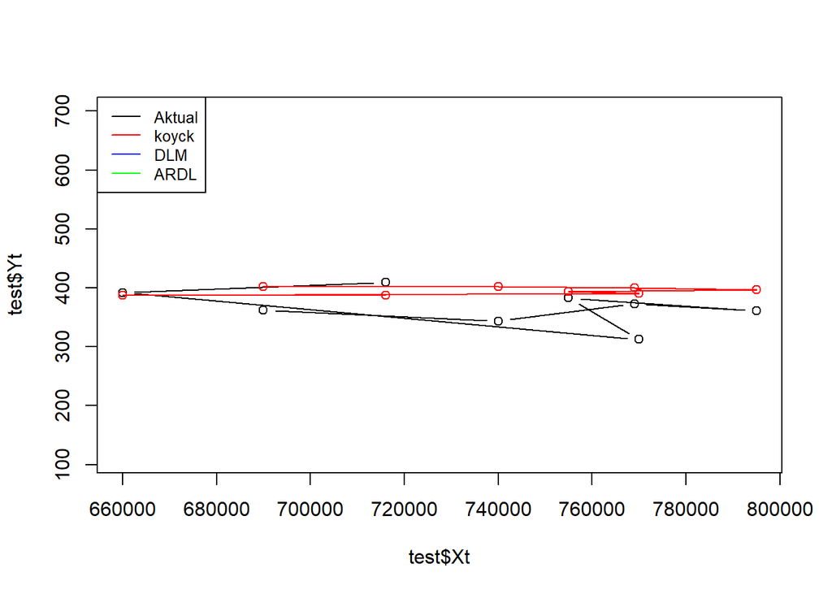

```r
par(mfrow=c(1,1))
plot(test$Xt, test$Yt, type="b", col="black", ylim=c(110,700))
points(test$Xt, fore.koyck$forecasts,col="red")
lines(test$Xt, fore.koyck$forecasts,col="red")
points(test$Xt, model.dlm$forecasts,col="blue")
lines(test$Xt, model.dlm$forecasts,col="blue")
points(test$Xt, model.ardl$forecasts,col="green")
lines(test$Xt, model.ardl$forecasts,col="green")
legend("topleft",c("Aktual", "koyck","DLM", "ARDL"), lty=1, col=c("black","red","blue","green"), cex=0.8)
```

# Model Diagnostics

## Uji Non Autokorelasi

```r
#Breusch-Godfrey test
bgtest(model.koyck$model)
```

```
##
##  Breusch-Godfrey test for serial correlation of order up to 1
##
## data:  model.koyck$model
## LM test = 0.14091, df = 1, p-value = 0.7074
```

```r
#Durbin-Watson test
dwtest(model.koyck$model)
```

```
##
##  Durbin-Watson test
##
## data:  model.koyck$model
## DW = 1.7624, p-value = 0.1691
## alternative hypothesis: true autocorrelation is greater than 0
```

## Uji heterogenitas

```r
bptest(model.koyck$model)
```

```
##
##  studentized Breusch-Pagan test
##
## data:  model.koyck$model
## BP = 2.2138, df = 2, p-value = 0.3306
```

Berdasarkan uji Breusch-Pagan dihasilkan nilai p-value = 0.3306 > alpha 5% sehingga tidak terjadi heteroskedastisitas pada model.

## Uji Normalitas

```r
ks.test(model.koyck$model$residuals, "pnorm")
```

```
##
##  Exact one-sample Kolmogorov-Smirnov test
##
## data:  model.koyck$model$residuals
## D = 0.5, p-value = 6.368e-08
## alternative hypothesis: two-sided
```

Berdasarkan uji Kolmogorov-Smirnov dihasilkan nilai p-value = 6.368e-08 < alpha 5% sehingga sisaan tidak menyebar normal.